# Master en Big Data. Fundamentos Matemáticos del Análisis de Datos (FMAD).

La variable table la tratamos como variable continua por el rango de valores que oscila.

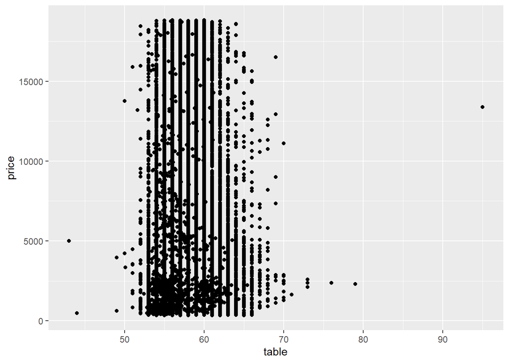

```r
ggplot(diamonds, aes(x = table, y = price)) +
  geom_point()
```

En este último gráfico de dispersión, no se ve ninguna tendencia ni indicio que sugiera que existe una relación entre la variable table y price. El caso, en cierta forma, es similar al de depth, con una variabilidad de precios muy alta para cada valor de table.

VARIABLES CATEGÓRICAS (Boxplot):

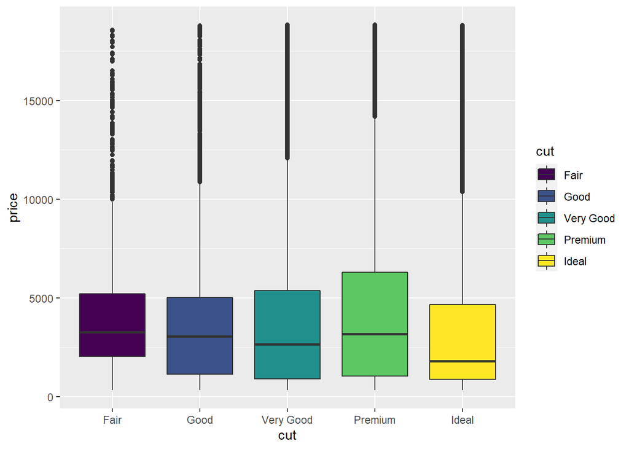

```r
ggplot(diamonds, aes(x = cut, y = price)) +
  geom_boxplot(aes(fill=cut))
```

En este caso, tenemos la variable categórica ‘cut’, que ya se encuentra ordenada en función de la calidad del corte.

Al estudiar el gráfico, nos damos cuenta de que el rango de precios no varía demasiado en función del corte, ya que que la variabilidad entre los niveles de la variable cut es reducida. Debido a esto, a priori, la variable cut no será considerada como un factor influyente en la predicción del precio del diamante.

Sí que es verdad, que conviene destacar que el corte ideal, que pensabamos que sería el más caro, tiene la mediana por debajo del resto, y habrá que descubrir el porqué.

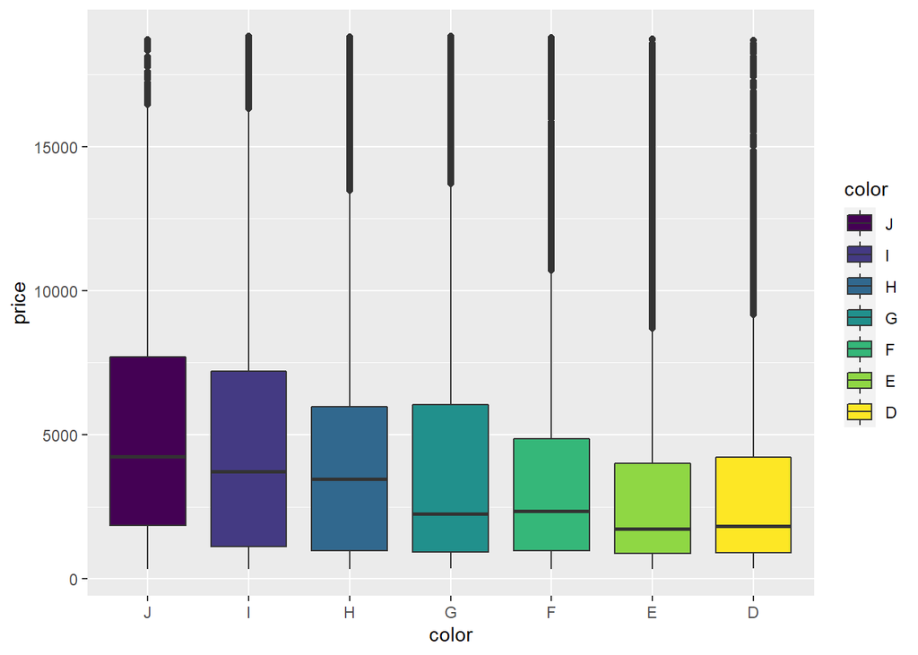

```r
diamonds %>%
  mutate(color = fct_rev(color)) %>%
  ggplot(aes(x = color, y = price)) +
  geom_boxplot(aes(fill=color))
```

En cuanto a este caso, primero decir que se utiliza la función fct_rev() para ordenar los niveles de la variable color de forma ascendente a lo largo del eje X, y de esta forma poder analizar si es un factor influyente o no en el establecimiento del precio del diamante.

Se ve que cuanto peor es el color, la variabilidad aumenta y el rango de precios q se oscila parece mayor, lo que es algo confuso a priori. Por este motivo, se puede concluir que existe una relación negativa débil entre estas variables, aunque nada demasiado relevante para el análsis.

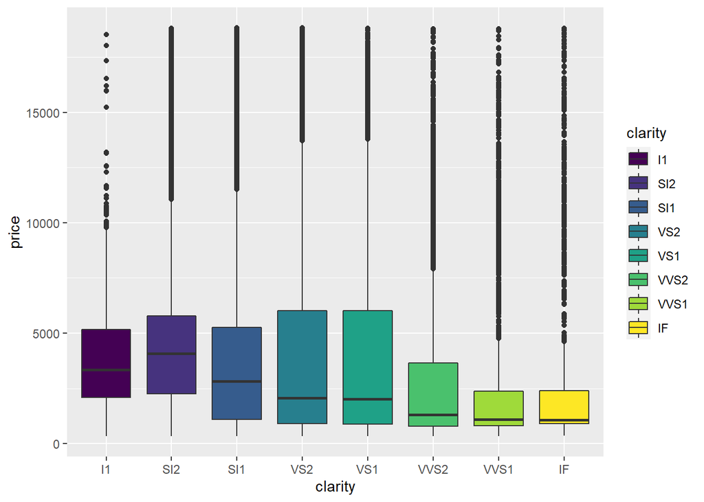

```r
ggplot(data = diamonds) +
  geom_boxplot(mapping = aes(x = clarity, y = price,fill=clarity))
```

En esta última variable que se va a estudiar, los niveles de claridad también se encuentran ordenados de peor(I1) a mejor(IF), por lo que directamente procedemos a la realización de la gráfica.

En este caso, también se aprecia una débil relación negativa entre ambas variables, pero tampoco es tan influyente como para que la claridad sea considerada como la mejor variable predictora para el precio. Por lo tanto, la relación no parece que sea significativa.

Las 2 últimas variables, en definitiva, tienen una gran variabilidad dentro de cada boxplot (nivel) y poca entre ellas.

CONCLUSION

Teniendo en cuenta las consideraciones realizadas en cada uno de las representaciones gráficas, carat parece que es la mejor variable predictora de cara a conocer el precio de un diamante.

2. Como se relaciona la variable cut con el carat ?

Analizamos la correlación entre ambas variables a través de un boxplot, como hemos hecho hasta ahora en el caso de una variable continua con una categórica.

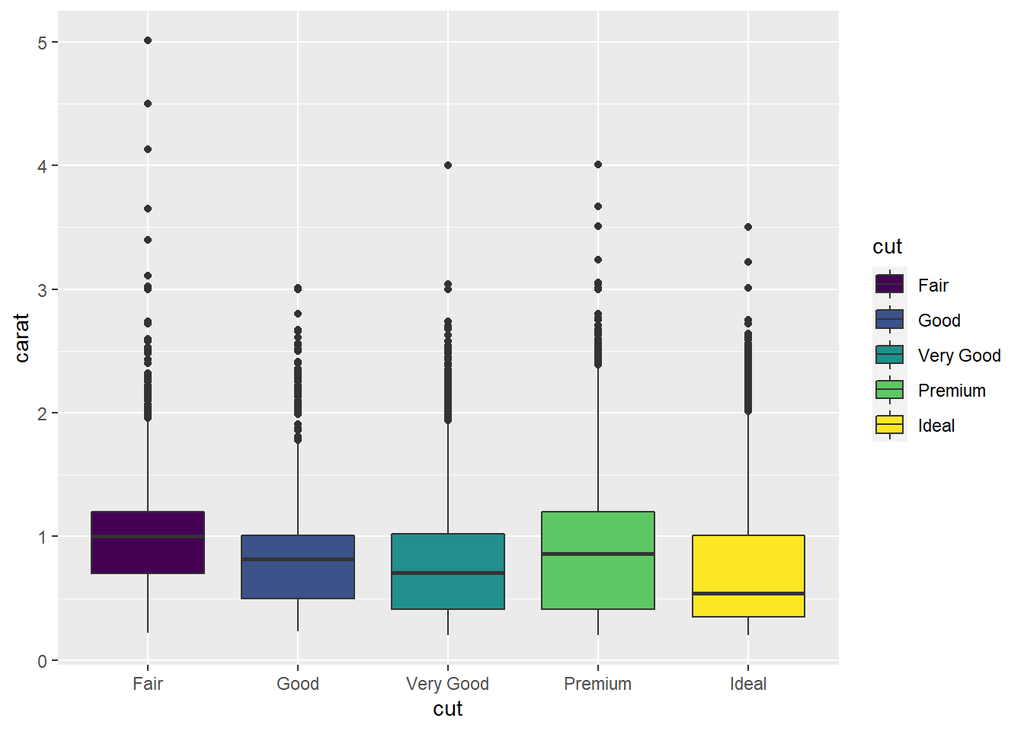

```r
ggplot(diamonds, aes(x = cut, y = carat)) +
  geom_boxplot(aes(fill=cut))
```

En este gráfico, se puede apreciar gran variabilidad en cuanto a los quilates en cada una de las categorías de corte, y en términos generales, una relación negativa leve entre ambas (variables), de forma que aquellos de más quilates, tienden a tener un corte de menor calidad (Fair).

3)¿Por qué la combinación de estas dos relaciones hace que los diamantes de menor calidad sean más caros?

Lo que se puede concluir en este aspecto, con todo el conjunto de gráficos y representaciones elaboradas, es que cuanto menor es la calidad del corte, por lo general, la variable carat alcanza valores más elevados, influyendo de forma directa sobre el precio establecido para cada diamante, y provocando que aquellos de menor calidad acaben siendo más caros. Al final, en la primera pregunta, hemos respondido haciendo referencia al hecho de que los quilates son la mejor variable predictora de cara a conocer el precio del diamante.

- Haz el [ejercicio 4 de la Sección 12.6.1 de R4DS](https://r4ds.had.co.nz/tidy-data.html#exercises-27). ¡Aprovecha el código previo de esa sección para trabajar con datos limpios!

Empezamos copiando el código previo al ejercicio para poder trabajar con datos limpios:

```r
(who_Ejer=who %>%
  pivot_longer(
    cols = new_sp_m014:newrel_f65,
    names_to = "key",
    values_to = "cases",
    values_drop_na = TRUE
  ) %>%
  mutate(
    key = stringr::str_replace(key, "newrel", "new_rel")
  ) %>%
  separate(key, c("new", "var", "sexage")) %>%
  select(-new, -iso2, -iso3) %>%
  separate(sexage, c("sex", "age"), sep = 1))
```

```
## # A tibble: 76,046 x 6
##    country      year var   sex   age   cases
##    <chr>       <int> <chr> <chr> <chr> <int>
##  1 Afghanistan  1997 sp    m     014       0
##  2 Afghanistan  1997 sp    m     1524     10
##  3 Afghanistan  1997 sp    m     2534      6
##  4 Afghanistan  1997 sp    m     3544      3
##  5 Afghanistan  1997 sp    m     4554      5
##  6 Afghanistan  1997 sp    m     5564      2
##  7 Afghanistan  1997 sp    m     65        0
##  8 Afghanistan  1997 sp    f     014       5
##  9 Afghanistan  1997 sp    f     1524     38
## 10 Afghanistan  1997 sp    f     2534     36
## # ... with 76,036 more rows
```

Calculamos el numero total de casos, agrupados por sexo, país y año, obteniendo como resultado el siguiente DataFrame:

```r
(who_TABLE=who_Ejer %>%
  group_by(country, year, sex) %>%
  summarise(cases = sum(cases)))
```

```
## # A tibble: 6,921 x 4
## # Groups:   country, year [3,484]
##    country      year sex   cases
##    <chr>       <int> <chr> <int>
##  1 Afghanistan  1997 f       102
##  2 Afghanistan  1997 m        26
##  3 Afghanistan  1998 f      1207
##  4 Afghanistan  1998 m       571
##  5 Afghanistan  1999 f       517
##  6 Afghanistan  1999 m       228
##  7 Afghanistan  2000 f      1751
##  8 Afghanistan  2000 m       915
##  9 Afghanistan  2001 f      3062
## 10 Afghanistan  2001 m      1577
## # ... with 6,911 more rows
```

Para la visualización de la información que nos aporta la tabla realizada, haremos uso de un gráfico temporal como el que se verá a continuación.

Las columnas sex y country se juntan para que cada línea del gráfico represente la evolución temporal de los casos de TB en cada país para cada género.

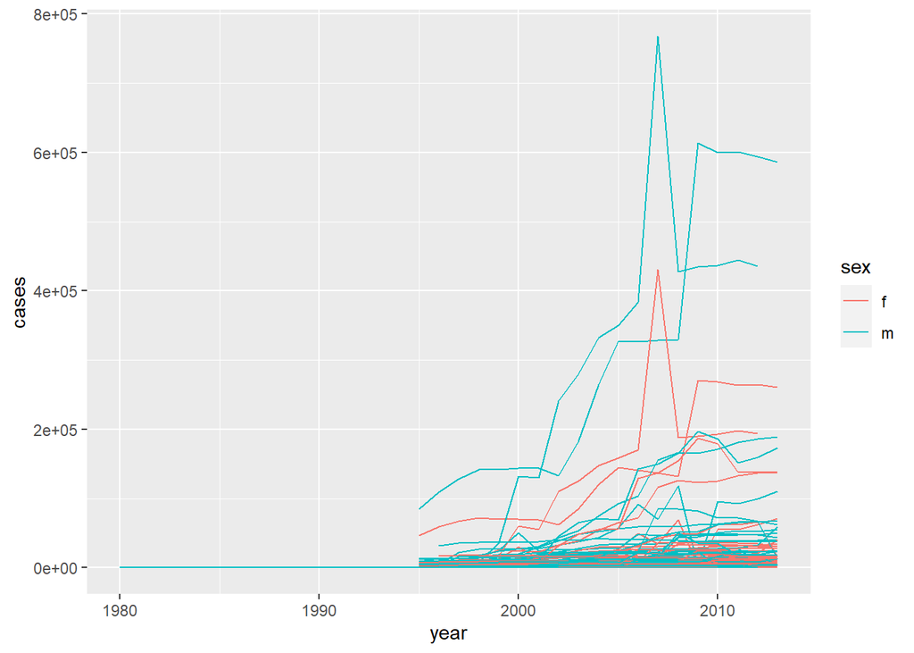

```r
who_TABLE  %>%
  unite(pais_genero, country, sex, remove = FALSE) %>%
  ggplot(aes(x = year, y = cases, group = pais_genero, colour = sex)) +
  geom_line()
```

Claramente, se puede ver como, aproximadamente hasta el año 1995, hay países que no disponen de registros en el dataset o que el número de casos es muy reducido y constante, por lo que no interesa incluirlos en el estudio. Nos centraremos en las evoluciones que han sufrido a partir del 95.

```r
(who_TABLE1=who_Ejer %>%
  group_by(country, year, sex) %>%
  filter(year > 1995) %>%
  summarise(cases = sum(cases)))
```

```
## # A tibble: 6,594 x 4
## # Groups:   country, year [3,320]
##    country      year sex   cases
##    <chr>       <int> <chr> <int>
##  1 Afghanistan  1997 f       102
##  2 Afghanistan  1997 m        26
##  3 Afghanistan  1998 f      1207
##  4 Afghanistan  1998 m       571
##  5 Afghanistan  1999 f       517
##  6 Afghanistan  1999 m       228
##  7 Afghanistan  2000 f      1751
##  8 Afghanistan  2000 m       915
##  9 Afghanistan  2001 f      3062
## 10 Afghanistan  2001 m      1577
## # ... with 6,584 more rows
```

Trabajaremos con este nuevo DataFrame

Volvemos a realizar el gráfico temporal, pero centrándonos en el número de casos a partir del año 1995, como se ha comentado previamente.

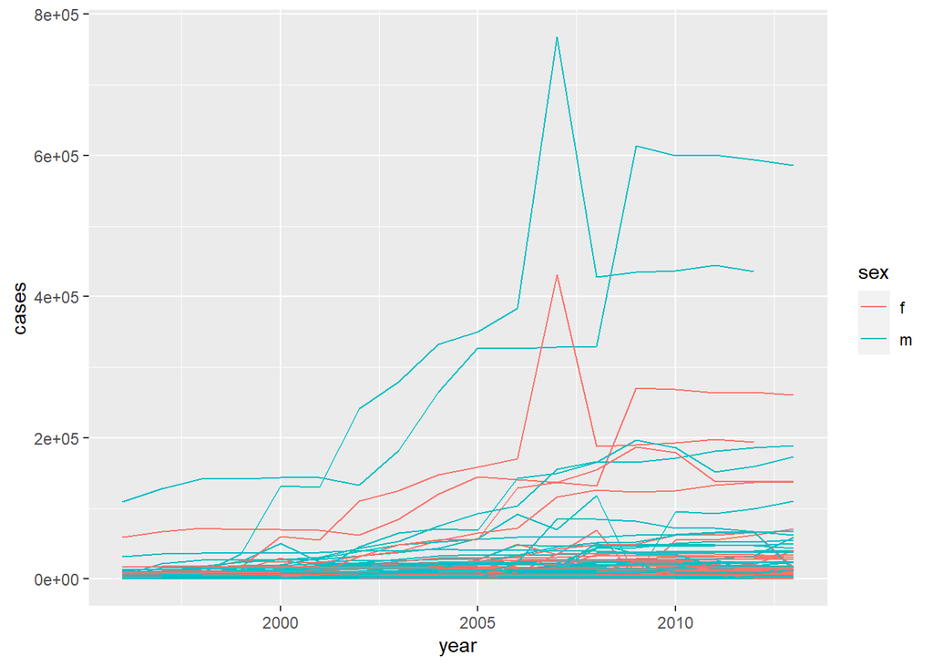

```r
who_TABLE1  %>%
  unite(pais_genero, country, sex, remove = FALSE) %>%
  ggplot(aes(x = year, y = cases, group = pais_genero, colour = sex)) +
  geom_line()
```

En este gráfico, vemos la evolución de cada sexo en cada país en lo referente a los casos de TB, aunque no se aprecia una distinción clara entre los países que están siendo representados.

Por lo tanto, a continuación se procede con la selección de aquellos que en total superan los 500K casos.

```r
(paisesTopCases = who_Ejer %>%
  group_by(country) %>%
  summarise(n=sum(cases)) %>%
  filter(n>500000)  %>%
  select(country))
```

```
## # A tibble: 16 x 1
##    country
##    <chr>
##  1 Bangladesh
##  2 Brazil
##  3 China
##  4 Democratic People's Republic of Korea
##  5 Democratic Republic of the Congo
##  6 Ethiopia
##  7 India
##  8 Indonesia
##  9 Kenya
## 10 Nigeria
## 11 Pakistan
## 12 Philippines
## 13 Russian Federation
## 14 South Africa
## 15 United Republic of Tanzania
## 16 Viet Nam
```

Finalmente, se representan los gráficos temporales para cada país (de los seleccionados previamente) en función del sexo, y cada uno con su escala correspondiente, para poder estudiar con claridad y alto nivel de detalle la evolución y tendencia de forma independiente.

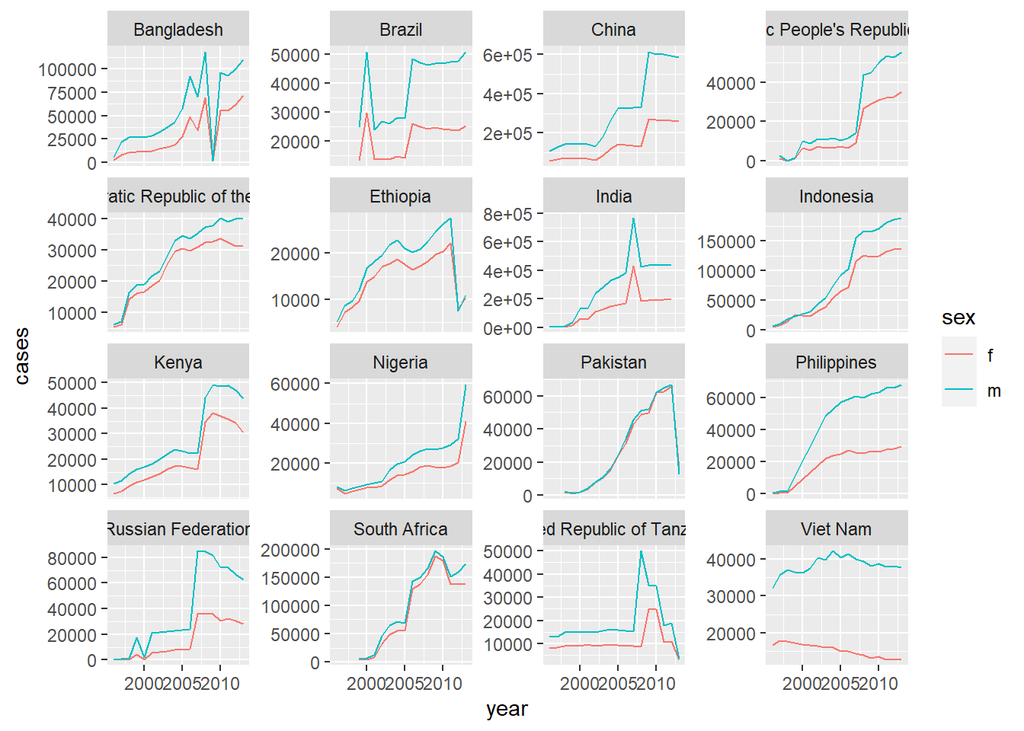

```r
who_TABLE1  %>%
  filter(country %in% paisesTopCases$country) %>%
  unite(pais_genero, country, sex, remove = FALSE) %>%
  ggplot(aes(x = year, y = cases, group = pais_genero, colour = sex)) +
  geom_line() +
  facet_wrap(~ country,scales='free_y')
```